# 1. Introduction

This notebook is intended to help decide where to have dinner in San Francisco, safely. The data used for this are:

1. [Foursquare API](https://developer.foursquare.com/docs/api/venues/explore)
2. [SF Police Department Incident Reports: 2018 to Present](https://data.sfgov.org/Public-Safety/Police-Department-Incident-Reports-2018-to-Present/wg3w-h783)

The final product of the notebook is an interactive map of SF, with districts colored by crime rate and markers showing restaurants, as well as sample crimes in the vicinity.

## 1.1. Crime dataset exploration

The dataset published by the SFPD includes important information regarding the incident (e.g. category) as well as its location. Most of the data in the 34 columns of this dataset (shown in table tbl. 1) will be useless for the purpose of this notebook, so only `Police District`, `Latitude`, `Longitude` and `Incident Category` will be retained, as illustrated in table tbl. 2.

**Table 1:** Top 5 rows of the original SFPD crimes dataset

|  | Incident Datetime | Incident Date | Incident Time | Incident Year | Incident Day of Week | Report Datetime | Row ID | Incident ID | Incident Number | CAD Number | ... | Longitude | point | SF Find Neighborhoods | Current Police Districts | Current Supervisor Districts | Analysis Neighborhoods | HSOC Zones as of 2018-06-05 | OWED Public Spaces | Central Market/Tenderloin Boundary Polygon - Updated | Parks Alliance CPSI (27+TL sites) |
| --- | --- | --- | --- | --- | --- | --- | --- | --- | --- | --- | --- | --- | --- | --- | --- | --- | --- | --- | --- | --- | --- |
| 0 | 2018/12/02 12:45:00 AM | 2018/12/02 | 00:45 | 2018 | Sunday | 2018/12/02 01:56:00 AM | 74374327130 | 743743 | 180908554 | 183360210.0 | ... | -122.404795 | (37.78490829943, -122.40479506276) | 32.0 | 5.0 | 10.0 | 8.0 | NaN | NaN | NaN | NaN |
| 1 | 2018/12/01 08:30:00 PM | 2018/12/01 | 20:30 | 2018 | Saturday | 2018/12/01 09:18:00 PM | 74370071000 | 743700 | 180908112 | 183353564.0 | ... | -122.408036 | (37.786409612811, -122.408036237445) | 19.0 | 6.0 | 3.0 | 36.0 | NaN | NaN | 1.0 | NaN |
| 2 | 2019/03/18 02:01:00 PM | 2019/03/18 | 14:01 | 2019 | Monday | 2019/03/18 02:21:00 PM | 78164004134 | 781640 | 190194129 | 190772267.0 | ... | -122.406699 | (37.756833733806, -122.406699002688) | 53.0 | 3.0 | 2.0 | 20.0 | 3.0 | NaN | NaN | NaN |
| 3 | 2019/03/20 08:00:00 AM | 2019/03/20 | 08:00 | 2019 | Wednesday | 2019/03/20 02:06:00 PM | 78169706244 | 781697 | 190199583 | 190792201.0 | ... | -122.404865 | (37.78400661242, -122.404864795177) | 32.0 | 1.0 | 10.0 | 34.0 | NaN | NaN | NaN | NaN |
| 4 | 2019/03/12 01:30:00 PM | 2019/03/12 | 13:30 | 2019 | Tuesday | 2019/03/15 06:02:00 PM | 78154706372 | 781547 | 196055103 | NaN | ... | NaN | NaN | NaN | NaN | NaN | NaN | NaN | NaN | NaN | NaN |

5 rows × 34 columns

**Table 2:** Top 5 rows, only relevant columns

|  | Police District | Latitude | Longitude | Incident Category |
| --- | --- | --- | --- | --- |
| 0 | Southern | 37.784908 | -122.404795 | Other Miscellaneous |
| 1 | Central | 37.786410 | -122.408036 | Lost Property |
| 2 | Mission | 37.756834 | -122.406699 | Assault |
| 3 | Southern | 37.784007 | -122.404865 | Larceny Theft |
| 4 | Central | NaN | NaN | Larceny Theft |

Some of the incidents reported are not relevant or to vague to include in the analysis, so they will be dropped. Incidents from categories `Gambling`, `Liquor Laws`, `Vehicle Impounded`, `Vehicle Misplaced`, `Case Closure`, `Other`, `Miscellaneous Investigation`, `Recovered Vehicle`, `Non-Criminal`, `Other Miscellaneous` amount to 36124 and after filtering the dataset is left with 158729 incidents. Table tbl. 3 shows number of incidents per category, also visualized in figure fig. 5. Figure fig. 4 shows the incident numbers per district and figure fig. 7 as well as table tbl. 6 show that information combined.

```
                             Incident Category  Count
0       Human Trafficking, Commercial Sex Acts      5
1                              Weapons Offence      6
2                                     Homicide     30
3                                   Suspicious     32
4                         Motor Vehicle Theft?     37
5                                         Rape     56
6                               Drug Violation     61
7                                      Suicide     81
8   Human Trafficking (A), Commercial Sex Acts     85
9                              Courtesy Report    131
10                                 Fire Report    189
11                                   Vandalism    235
12                                Embezzlement    236
13                              Family Offense    255
```

[output cut: 26 more lines]

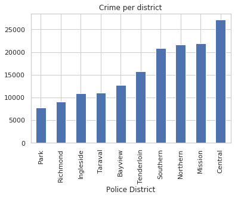

**Figure 4:** Number of crimes per district

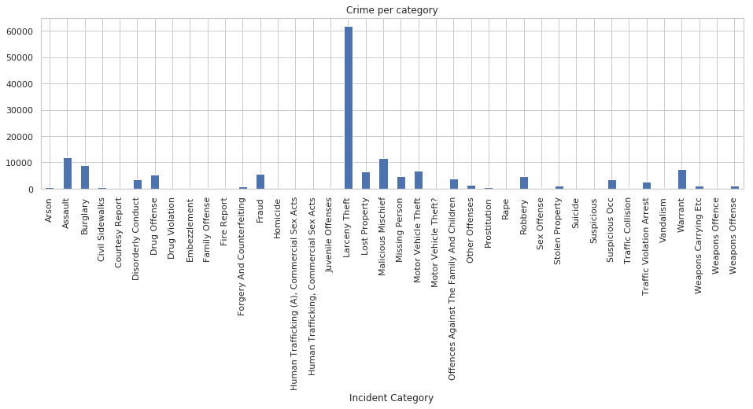

**Figure 5:** Crime per category

**Table 6:** Incident count grouped by category and district.

|  | Incident Category | Police District | count |
| --- | --- | --- | --- |
| 0 | Larceny Theft | Central | 14091 |
| 1 | Larceny Theft | Northern | 11128 |
| 2 | Larceny Theft | Southern | 8234 |
| 3 | Larceny Theft | Mission | 7334 |
| 4 | Larceny Theft | Richmond | 4533 |
| 5 | Larceny Theft | Taraval | 3866 |
| 6 | Larceny Theft | Tenderloin | 3734 |
| 7 | Larceny Theft | Bayview | 3487 |
| 8 | Larceny Theft | Ingleside | 2792 |
| 9 | Larceny Theft | Park | 2703 |

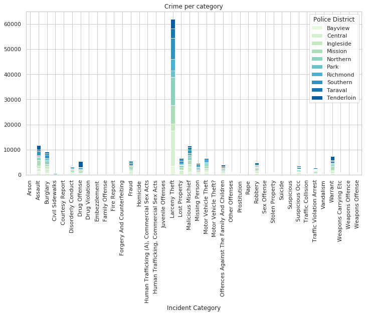

**Figure 7:** Number of crimes per category and district

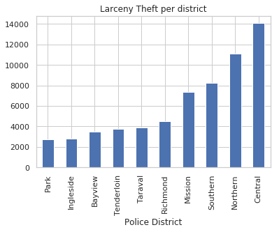

## 1.2. Crime dataset summary

Most important information regarding crime rate per category and district is shown in table tbl. 9.

**Table 9:** Incident count grouped by category and district.

| Police District Incident Category | Bayview | Central | Ingleside | Mission | Northern | Park | Richmond | Southern | Taraval | Tenderloin |
| --- | --- | --- | --- | --- | --- | --- | --- | --- | --- | --- |
| Arson | 73.0 | 65.0 | 44.0 | 60.0 | 37.0 | 12.0 | 24.0 | 60.0 | 22.0 | 56.0 |
| Assault | 1311.0 | 1363.0 | 944.0 | 2054.0 | 1253.0 | 430.0 | 363.0 | 1586.0 | 694.0 | 1815.0 |
| Burglary | 833.0 | 1590.0 | 857.0 | 910.0 | 1358.0 | 491.0 | 449.0 | 1407.0 | 753.0 | 429.0 |
| Civil Sidewalks | NaN | 15.0 | NaN | 168.0 | 3.0 | 437.0 | 8.0 | 6.0 | NaN | 3.0 |
| Courtesy Report | 17.0 | 20.0 | 11.0 | 16.0 | 9.0 | 6.0 | 12.0 | 15.0 | 12.0 | 13.0 |
| Disorderly Conduct | 375.0 | 420.0 | 337.0 | 608.0 | 378.0 | 115.0 | 161.0 | 422.0 | 291.0 | 323.0 |
| Drug Offense | 188.0 | 375.0 | 216.0 | 791.0 | 347.0 | 181.0 | 85.0 | 664.0 | 112.0 | 2402.0 |
| Drug Violation | 8.0 | 3.0 | 9.0 | 8.0 | 2.0 | 1.0 | NaN | 8.0 | NaN | 22.0 |
| Embezzlement | 28.0 | 37.0 | 10.0 | 28.0 | 19.0 | 7.0 | 15.0 | 41.0 | 16.0 | 35.0 |
| Family Offense | 67.0 | 13.0 | 27.0 | 40.0 | 19.0 | 6.0 | 20.0 | 18.0 | 29.0 | 16.0 |
| Fire Report | 38.0 | 19.0 | 26.0 | 27.0 | 11.0 | 8.0 | 9.0 | 24.0 | 16.0 | 11.0 |
| Forgery And Counterfeiting | 57.0 | 156.0 | 69.0 | 143.0 | 113.0 | 34.0 | 49.0 | 136.0 | 58.0 | 67.0 |
| Fraud | 360.0 | 973.0 | 464.0 | 601.0 | 760.0 | 262.0 | 396.0 | 693.0 | 750.0 | 369.0 |
| Homicide | 6.0 | 3.0 | 1.0 | 6.0 | 2.0 | NaN | 1.0 | 3.0 | 4.0 | 4.0 |
| Human Trafficking (A), Commercial Sex Acts | 1.0 | 13.0 | 1.0 | 10.0 | 3.0 | NaN | NaN | 34.0 | 20.0 | 3.0 |
| Human Trafficking, Commercial Sex Acts | NaN | NaN | 1.0 | 1.0 | NaN | NaN | NaN | 3.0 | NaN | NaN |
| Juvenile Offenses | 12.0 | 1.0 | 17.0 | 10.0 | 11.0 | 26.0 | 15.0 | 7.0 | 158.0 | 6.0 |
| Larceny Theft | 3487.0 | 14091.0 | 2792.0 | 7334.0 | 11128.0 | 2703.0 | 4533.0 | 8234.0 | 3866.0 | 3734.0 |
| Lost Property | 285.0 | 1461.0 | 314.0 | 939.0 | 793.0 | 235.0 | 373.0 | 1032.0 | 464.0 | 694.0 |
| Malicious Mischief | 1275.0 | 1915.0 | 983.0 | 1540.0 | 1512.0 | 565.0 | 682.0 | 1570.0 | 828.0 | 719.0 |
| Missing Person | 392.0 | 327.0 | 420.0 | 580.0 | 436.0 | 642.0 | 223.0 | 582.0 | 661.0 | 385.0 |
| Motor Vehicle Theft | 1118.0 | 658.0 | 833.0 | 956.0 | 741.0 | 388.0 | 403.0 | 828.0 | 632.0 | 263.0 |
| Motor Vehicle Theft? | 4.0 | 5.0 | 7.0 | 7.0 | 3.0 | 1.0 | 1.0 | 3.0 | 4.0 | 2.0 |
| Offences Against The Family And Children | 466.0 | 364.0 | 472.0 | 539.0 | 456.0 | 141.0 | 200.0 | 412.0 | 380.0 | 456.0 |
| Other Offenses | 97.0 | 140.0 | 100.0 | 201.0 | 104.0 | 154.0 | 76.0 | 178.0 | 65.0 | 245.0 |
| Prostitution | NaN | 117.0 | 2.0 | 284.0 | 8.0 | NaN | NaN | 65.0 | 46.0 | 47.0 |
| Rape | 4.0 | 2.0 | 3.0 | 12.0 | 6.0 | 2.0 | 2.0 | 16.0 | 3.0 | 6.0 |
| Robbery | 523.0 | 801.0 | 496.0 | 685.0 | 548.0 | 104.0 | 143.0 | 486.0 | 213.0 | 719.0 |
| Sex Offense | 25.0 | 38.0 | 29.0 | 64.0 | 55.0 | 17.0 | 9.0 | 91.0 | 28.0 | 46.0 |
| Stolen Property | 97.0 | 207.0 | 75.0 | 141.0 | 150.0 | 28.0 | 49.0 | 125.0 | 52.0 | 113.0 |
| Suicide | 5.0 | 9.0 | 7.0 | 8.0 | 13.0 | 4.0 | 10.0 | 12.0 | 8.0 | 5.0 |
| Suspicious | 1.0 | 4.0 | NaN | 1.0 | 1.0 | 1.0 | 5.0 | 18.0 | 1.0 | NaN |
| Suspicious Occ | 413.0 | 501.0 | 315.0 | 450.0 | 275.0 | 146.0 | 292.0 | 529.0 | 249.0 | 408.0 |
| Traffic Collision | 55.0 | 39.0 | 46.0 | 53.0 | 41.0 | 16.0 | 29.0 | 31.0 | 26.0 | 18.0 |
| Traffic Violation Arrest | 160.0 | 258.0 | 342.0 | 693.0 | 186.0 | 115.0 | 162.0 | 317.0 | 181.0 | 307.0 |
| Vandalism | 19.0 | 27.0 | 17.0 | 42.0 | 36.0 | 17.0 | 14.0 | 29.0 | 23.0 | 11.0 |
| Warrant | 553.0 | 890.0 | 411.0 | 1462.0 | 651.0 | 349.0 | 184.0 | 943.0 | 251.0 | 1729.0 |
| Weapons Carrying Etc | 178.0 | 113.0 | 139.0 | 199.0 | 83.0 | 12.0 | 26.0 | 93.0 | 58.0 | 181.0 |
| Weapons Offence | NaN | 2.0 | NaN | 2.0 | NaN | NaN | NaN | NaN | 1.0 | 1.0 |
| Weapons Offense | 172.0 | 96.0 | 119.0 | 203.0 | 80.0 | 35.0 | 41.0 | 134.0 | 54.0 | 113.0 |

# 2. Venues dataset exploration

For each of the districts in the SFPD dataset a single incident was randomly selected in order to get its latitude and longitude, which the serve to query the Foursquare API. Again the full dataset consist 31 columns, of which only several (`['venue.location.lat','venue.location.lng','venue.name']`) will be useful for the purpose of this analysis, other columns will be dropped, as well as locations with NaN coordinates. At the time of writing of this report - the venue dataset consisted of 884 restaurants.

```
777
```

```
478
```

|  | Police District | venue.location.lat | venue.location.lng | venue.name | venue.id | rating |
| --- | --- | --- | --- | --- | --- | --- |
| 0 | Bayview | 37.734826 | -122.390764 | Radio Africa & Kitchen | 4f56b36a6b7406c0ea010e9b | 8.4 |
| 1 | Bayview | 37.736240 | -122.390361 | TATO | 5b89f7f6a0215b002c7cfd73 | 8.4 |
| 2 | Bayview | 37.726908 | -122.391536 | Craftsman and Wolves Den | 5703cab0498e52dae7c36bcf | 8.2 |
| 3 | Bayview | 37.732747 | -122.392245 | Fox and Lion Bakery | 5618351f498e69559d3990b7 | 7.8 |
| 4 | Bayview | 37.734287 | -122.390462 | Old Skool Cafe | 4d0401f454d0236aa38cecd5 | 7.4 |

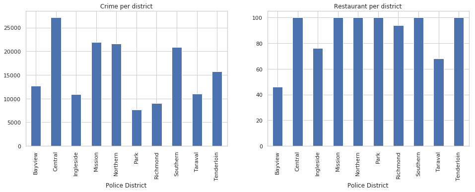

[interactive chart not shown]

```
GeoJSON file downloaded!
```

[interactive chart not shown]

## 2.1. Explore highest rated restaurants by district

As the first step to choose the best place to dine we will look into how ratings per district are distributed.

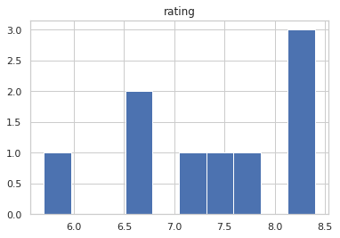

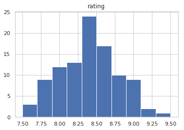

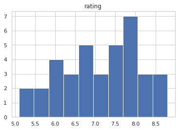

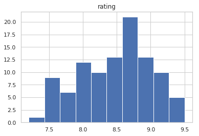

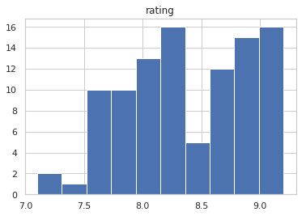

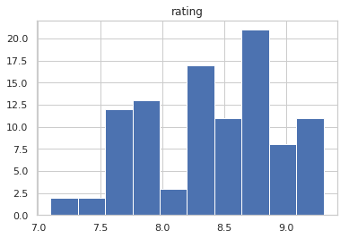

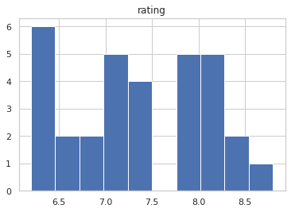

**Table 28:** Venues count by district and rating count

| Police District rating | Bayview | Central | Ingleside | Mission | Northern | Park | Richmond |
| --- | --- | --- | --- | --- | --- | --- | --- |
| (5, 6] | 1 | 0 | 4 | 0 | 0 | 0 | 0 |
| (6, 7] | 2 | 0 | 13 | 0 | 0 | 0 | 12 |
| (7, 8] | 3 | 24 | 14 | 24 | 28 | 31 | 12 |
| (8, 9] | 3 | 73 | 6 | 61 | 63 | 58 | 8 |
| (9, 10] | 0 | 3 | 0 | 15 | 9 | 11 | 0 |

Based on table tbl. 28 - the districts that have the highest rated venues are Central and Mission, however these are also heavily influenced by crime, as shown in figure fig. 4. We need to select the neighborhood with best food and relatively low crime. Northern district is 2nd in terms of number of highly rated venues and 3rd in crime rate, however Park district has lowest crime yet pretty decent food, as well.

# 3. Conclusions

Based on analysis of the crime data and venue information provided via Foursquare API we were able to determine that the Park district is the safest (disregarding the kind of incidents, only looking at the volume) while having relatively decent restaurants.

[interactive chart not shown]